# Risk Factor Analysis

## Outcome Variable

**Outcome Variable:** ever_wasted

## Predictor Variables

**Intervention Variable:** cleanck

**Adjustment Set:**

- arm
- sex
- W_mage
- meducyrs
- feducyrs
- hhwealth_quart
- W_nrooms
- W_nhh
- W_nchldlt5
- trth2o
- impfloor
- delta_meducyrs
- delta_feducyrs
- delta_hhwealth_quart
- delta_W_nrooms
- delta_W_nhh
- delta_W_nchldlt5
- delta_trth2o
- delta_impfloor

## Stratifying Variables

The analysis was stratified on these variable(s):

- agecat
- studyid
- country

## Data Summary

| agecat | studyid | country | cleanck | ever_wasted | n_cell | n |
| --- | --- | --- | --- | --- | --- | --- |
| 0-24 months (no birth wast) | CMC-V-BCS-2002 | INDIA | 1 | 0 | 104 | 368 |
| 0-24 months (no birth wast) | CMC-V-BCS-2002 | INDIA | 1 | 1 | 59 | 368 |
| 0-24 months (no birth wast) | CMC-V-BCS-2002 | INDIA | 0 | 0 | 98 | 368 |
| 0-24 months (no birth wast) | CMC-V-BCS-2002 | INDIA | 0 | 1 | 107 | 368 |
| 0-24 months (no birth wast) | GMS-Nepal | NEPAL | 1 | 0 | 7 | 589 |
| 0-24 months (no birth wast) | GMS-Nepal | NEPAL | 1 | 1 | 2 | 589 |
| 0-24 months (no birth wast) | GMS-Nepal | NEPAL | 0 | 0 | 279 | 589 |
| 0-24 months (no birth wast) | GMS-Nepal | NEPAL | 0 | 1 | 301 | 589 |
| 0-24 months (no birth wast) | IRC | INDIA | 1 | 0 | 107 | 399 |
| 0-24 months (no birth wast) | IRC | INDIA | 1 | 1 | 123 | 399 |
| 0-24 months (no birth wast) | IRC | INDIA | 0 | 0 | 84 | 399 |
| 0-24 months (no birth wast) | IRC | INDIA | 0 | 1 | 85 | 399 |
| 0-24 months (no birth wast) | MAL-ED | PERU | 1 | 0 | 1 | 2 |
| 0-24 months (no birth wast) | MAL-ED | PERU | 1 | 1 | 0 | 2 |
| 0-24 months (no birth wast) | MAL-ED | PERU | 0 | 0 | 1 | 2 |
| 0-24 months (no birth wast) | MAL-ED | PERU | 0 | 1 | 0 | 2 |
| 0-24 months (no birth wast) | MAL-ED | SOUTH AFRICA | 1 | 0 | 2 | 3 |
| 0-24 months (no birth wast) | MAL-ED | SOUTH AFRICA | 1 | 1 | 0 | 3 |
| 0-24 months (no birth wast) | MAL-ED | SOUTH AFRICA | 0 | 0 | 1 | 3 |
| 0-24 months (no birth wast) | MAL-ED | SOUTH AFRICA | 0 | 1 | 0 | 3 |
| 0-24 months (no birth wast) | NIH-Crypto | BANGLADESH | 1 | 0 | 319 | 575 |
| 0-24 months (no birth wast) | NIH-Crypto | BANGLADESH | 1 | 1 | 39 | 575 |
| 0-24 months (no birth wast) | NIH-Crypto | BANGLADESH | 0 | 0 | 181 | 575 |
| 0-24 months (no birth wast) | NIH-Crypto | BANGLADESH | 0 | 1 | 36 | 575 |
| 0-24 months (no birth wast) | PROVIDE | BANGLADESH | 1 | 0 | 471 | 687 |
| 0-24 months (no birth wast) | PROVIDE | BANGLADESH | 1 | 1 | 90 | 687 |
| 0-24 months (no birth wast) | PROVIDE | BANGLADESH | 0 | 0 | 94 | 687 |
| 0-24 months (no birth wast) | PROVIDE | BANGLADESH | 0 | 1 | 32 | 687 |
| 0-6 months (no birth wast) | CMC-V-BCS-2002 | INDIA | 1 | 0 | 117 | 350 |
| 0-6 months (no birth wast) | CMC-V-BCS-2002 | INDIA | 1 | 1 | 40 | 350 |
| 0-6 months (no birth wast) | CMC-V-BCS-2002 | INDIA | 0 | 0 | 125 | 350 |
| 0-6 months (no birth wast) | CMC-V-BCS-2002 | INDIA | 0 | 1 | 68 | 350 |
| 0-6 months (no birth wast) | GMS-Nepal | NEPAL | 1 | 0 | 7 | 576 |
| 0-6 months (no birth wast) | GMS-Nepal | NEPAL | 1 | 1 | 1 | 576 |
| 0-6 months (no birth wast) | GMS-Nepal | NEPAL | 0 | 0 | 456 | 576 |
| 0-6 months (no birth wast) | GMS-Nepal | NEPAL | 0 | 1 | 112 | 576 |
| 0-6 months (no birth wast) | IRC | INDIA | 1 | 0 | 136 | 381 |
| 0-6 months (no birth wast) | IRC | INDIA | 1 | 1 | 86 | 381 |
| 0-6 months (no birth wast) | IRC | INDIA | 0 | 0 | 115 | 381 |
| 0-6 months (no birth wast) | IRC | INDIA | 0 | 1 | 44 | 381 |
| 0-6 months (no birth wast) | MAL-ED | PERU | 1 | 0 | 1 | 2 |
| 0-6 months (no birth wast) | MAL-ED | PERU | 1 | 1 | 0 | 2 |
| 0-6 months (no birth wast) | MAL-ED | PERU | 0 | 0 | 1 | 2 |
| 0-6 months (no birth wast) | MAL-ED | PERU | 0 | 1 | 0 | 2 |
| 0-6 months (no birth wast) | MAL-ED | SOUTH AFRICA | 1 | 0 | 2 | 3 |
| 0-6 months (no birth wast) | MAL-ED | SOUTH AFRICA | 1 | 1 | 0 | 3 |
| 0-6 months (no birth wast) | MAL-ED | SOUTH AFRICA | 0 | 0 | 1 | 3 |
| 0-6 months (no birth wast) | MAL-ED | SOUTH AFRICA | 0 | 1 | 0 | 3 |
| 0-6 months (no birth wast) | NIH-Crypto | BANGLADESH | 1 | 0 | 351 | 572 |
| 0-6 months (no birth wast) | NIH-Crypto | BANGLADESH | 1 | 1 | 4 | 572 |
| 0-6 months (no birth wast) | NIH-Crypto | BANGLADESH | 0 | 0 | 208 | 572 |
| 0-6 months (no birth wast) | NIH-Crypto | BANGLADESH | 0 | 1 | 9 | 572 |
| 0-6 months (no birth wast) | PROVIDE | BANGLADESH | 1 | 0 | 530 | 683 |
| 0-6 months (no birth wast) | PROVIDE | BANGLADESH | 1 | 1 | 27 | 683 |
| 0-6 months (no birth wast) | PROVIDE | BANGLADESH | 0 | 0 | 116 | 683 |
| 0-6 months (no birth wast) | PROVIDE | BANGLADESH | 0 | 1 | 10 | 683 |

The following strata were considered:

- agecat: 0-24 months (no birth wast), studyid: CMC-V-BCS-2002, country: INDIA
- agecat: 0-24 months (no birth wast), studyid: GMS-Nepal, country: NEPAL
- agecat: 0-24 months (no birth wast), studyid: IRC, country: INDIA
- agecat: 0-24 months (no birth wast), studyid: MAL-ED, country: PERU
- agecat: 0-24 months (no birth wast), studyid: MAL-ED, country: SOUTH AFRICA
- agecat: 0-24 months (no birth wast), studyid: NIH-Crypto, country: BANGLADESH
- agecat: 0-24 months (no birth wast), studyid: PROVIDE, country: BANGLADESH
- agecat: 0-6 months (no birth wast), studyid: CMC-V-BCS-2002, country: INDIA
- agecat: 0-6 months (no birth wast), studyid: GMS-Nepal, country: NEPAL
- agecat: 0-6 months (no birth wast), studyid: IRC, country: INDIA
- agecat: 0-6 months (no birth wast), studyid: MAL-ED, country: PERU
- agecat: 0-6 months (no birth wast), studyid: MAL-ED, country: SOUTH AFRICA
- agecat: 0-6 months (no birth wast), studyid: NIH-Crypto, country: BANGLADESH
- agecat: 0-6 months (no birth wast), studyid: PROVIDE, country: BANGLADESH

### Dropped Strata

Some strata were dropped due to rare outcomes:

- agecat: 0-24 months (no birth wast), studyid: GMS-Nepal, country: NEPAL
- agecat: 0-24 months (no birth wast), studyid: MAL-ED, country: PERU
- agecat: 0-24 months (no birth wast), studyid: MAL-ED, country: SOUTH AFRICA
- agecat: 0-6 months (no birth wast), studyid: GMS-Nepal, country: NEPAL
- agecat: 0-6 months (no birth wast), studyid: MAL-ED, country: PERU
- agecat: 0-6 months (no birth wast), studyid: MAL-ED, country: SOUTH AFRICA
- agecat: 0-6 months (no birth wast), studyid: NIH-Crypto, country: BANGLADESH

## Methods Detail

We're interested in the causal parameters $E[Y_a]$ for all values of $a \in \mathcal{A}$. These parameters represent the mean outcome if, possibly contrary to fact, we intervened to set all units to have $A=a$. Under the randomization and positivity assumptions, these are identified by the statistical parameters $\psi_a=E_W[E_{Y|A,W}(Y|A=a,W)]$. In addition, we're interested in the mean of $Y$, $E[Y]$ under no intervention (the observed mean). We will estimate these parameters by using SuperLearner to fit the relevant likelihood factors -- $E_{Y|A,W}(Y|A=a,W)$ and $p(A=a|W)$, and then updating our likelihood fit using a joint TMLE.

For unadjusted analyses ($W=\{\}$), initial likelihoods were estimated using Lrnr_glm to estimate the simple $E(Y|A)$ and Lrnr_mean to estimate $p(A)$. For adjusted analyses, a small library containing Lrnr_glmnet, Lrnr_xgboost, and Lrnr_mean was used.

Having estimated these parameters, we will then use the delta method to estimate relative risks and attributable risks relative to a prespecified baseline level of $A$.

# Results Detail

## Results Plots

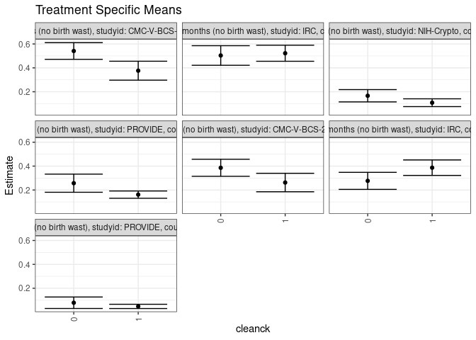

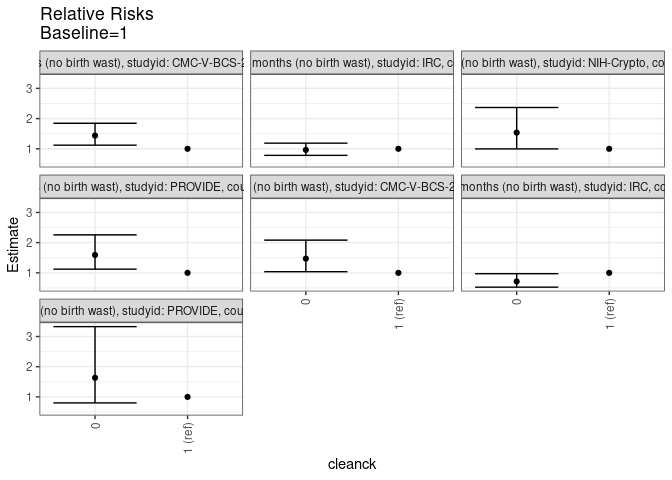

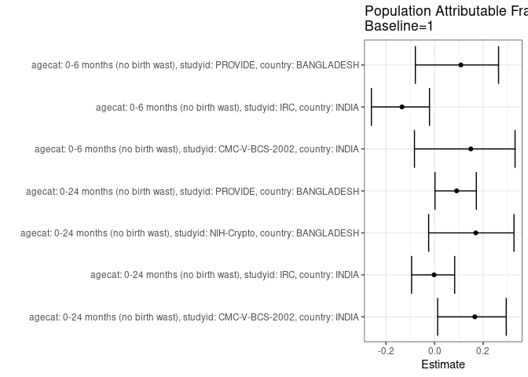

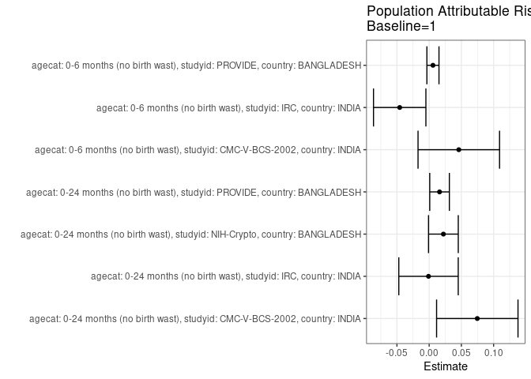

## Results Table

### Parameter: TSM

| agecat | studyid | country | intervention_level | baseline_level | estimate | ci_lower | ci_upper |
| --- | --- | --- | --- | --- | --- | --- | --- |
| 0-24 months (no birth wast) | CMC-V-BCS-2002 | INDIA | 1 | NA | 0.3763957 | 0.2971334 | 0.4556579 |
| 0-24 months (no birth wast) | CMC-V-BCS-2002 | INDIA | 0 | NA | 0.5411977 | 0.4713113 | 0.6110842 |
| 0-24 months (no birth wast) | IRC | INDIA | 1 | NA | 0.5223048 | 0.4550347 | 0.5895750 |
| 0-24 months (no birth wast) | IRC | INDIA | 0 | NA | 0.5036202 | 0.4215374 | 0.5857030 |
| 0-24 months (no birth wast) | NIH-Crypto | BANGLADESH | 1 | NA | 0.1083321 | 0.0756716 | 0.1409926 |
| 0-24 months (no birth wast) | NIH-Crypto | BANGLADESH | 0 | NA | 0.1664495 | 0.1149708 | 0.2179283 |
| 0-24 months (no birth wast) | PROVIDE | BANGLADESH | 1 | NA | 0.1614627 | 0.1310735 | 0.1918520 |
| 0-24 months (no birth wast) | PROVIDE | BANGLADESH | 0 | NA | 0.2570619 | 0.1811175 | 0.3330064 |
| 0-6 months (no birth wast) | CMC-V-BCS-2002 | INDIA | 1 | NA | 0.2625839 | 0.1853532 | 0.3398147 |
| 0-6 months (no birth wast) | CMC-V-BCS-2002 | INDIA | 0 | NA | 0.3860364 | 0.3146459 | 0.4574268 |
| 0-6 months (no birth wast) | IRC | INDIA | 1 | NA | 0.3869177 | 0.3220686 | 0.4517668 |
| 0-6 months (no birth wast) | IRC | INDIA | 0 | NA | 0.2765847 | 0.2051985 | 0.3479708 |
| 0-6 months (no birth wast) | PROVIDE | BANGLADESH | 1 | NA | 0.0483010 | 0.0304624 | 0.0661396 |
| 0-6 months (no birth wast) | PROVIDE | BANGLADESH | 0 | NA | 0.0788625 | 0.0309193 | 0.1268058 |

### Parameter: E(Y)

| agecat | studyid | country | intervention_level | baseline_level | estimate | ci_lower | ci_upper |
| --- | --- | --- | --- | --- | --- | --- | --- |
| 0-24 months (no birth wast) | CMC-V-BCS-2002 | INDIA | NA | NA | 0.4510870 | 0.4001777 | 0.5019962 |
| 0-24 months (no birth wast) | IRC | INDIA | NA | NA | 0.5213033 | 0.4722258 | 0.5703807 |
| 0-24 months (no birth wast) | NIH-Crypto | BANGLADESH | NA | NA | 0.1304348 | 0.1028836 | 0.1579859 |
| 0-24 months (no birth wast) | PROVIDE | BANGLADESH | NA | NA | 0.1775837 | 0.1489858 | 0.2061816 |
| 0-6 months (no birth wast) | CMC-V-BCS-2002 | INDIA | NA | NA | 0.3085714 | 0.2601110 | 0.3570318 |
| 0-6 months (no birth wast) | IRC | INDIA | NA | NA | 0.3412073 | 0.2935379 | 0.3888768 |
| 0-6 months (no birth wast) | PROVIDE | BANGLADESH | NA | NA | 0.0541728 | 0.0371844 | 0.0711612 |

### Parameter: RR

| agecat | studyid | country | intervention_level | baseline_level | estimate | ci_lower | ci_upper |
| --- | --- | --- | --- | --- | --- | --- | --- |
| 0-24 months (no birth wast) | CMC-V-BCS-2002 | INDIA | 1 | 1 | 1.0000000 | 1.0000000 | 1.0000000 |
| 0-24 months (no birth wast) | CMC-V-BCS-2002 | INDIA | 0 | 1 | 1.4378427 | 1.1205206 | 1.8450278 |
| 0-24 months (no birth wast) | IRC | INDIA | 1 | 1 | 1.0000000 | 1.0000000 | 1.0000000 |
| 0-24 months (no birth wast) | IRC | INDIA | 0 | 1 | 0.9642266 | 0.7831421 | 1.1871829 |
| 0-24 months (no birth wast) | NIH-Crypto | BANGLADESH | 1 | 1 | 1.0000000 | 1.0000000 | 1.0000000 |
| 0-24 months (no birth wast) | NIH-Crypto | BANGLADESH | 0 | 1 | 1.5364743 | 0.9971881 | 2.3674103 |
| 0-24 months (no birth wast) | PROVIDE | BANGLADESH | 1 | 1 | 1.0000000 | 1.0000000 | 1.0000000 |
| 0-24 months (no birth wast) | PROVIDE | BANGLADESH | 0 | 1 | 1.5920820 | 1.1227849 | 2.2575340 |
| 0-6 months (no birth wast) | CMC-V-BCS-2002 | INDIA | 1 | 1 | 1.0000000 | 1.0000000 | 1.0000000 |
| 0-6 months (no birth wast) | CMC-V-BCS-2002 | INDIA | 0 | 1 | 1.4701446 | 1.0376698 | 2.0828642 |
| 0-6 months (no birth wast) | IRC | INDIA | 1 | 1 | 1.0000000 | 1.0000000 | 1.0000000 |
| 0-6 months (no birth wast) | IRC | INDIA | 0 | 1 | 0.7148411 | 0.5256111 | 0.9721975 |
| 0-6 months (no birth wast) | PROVIDE | BANGLADESH | 1 | 1 | 1.0000000 | 1.0000000 | 1.0000000 |
| 0-6 months (no birth wast) | PROVIDE | BANGLADESH | 0 | 1 | 1.6327295 | 0.8015296 | 3.3258980 |

### Parameter: PAR

| agecat | studyid | country | intervention_level | baseline_level | estimate | ci_lower | ci_upper |
| --- | --- | --- | --- | --- | --- | --- | --- |
| 0-24 months (no birth wast) | CMC-V-BCS-2002 | INDIA | 1 | NA | 0.0746913 | 0.0115378 | 0.1378448 |
| 0-24 months (no birth wast) | IRC | INDIA | 1 | NA | -0.0010016 | -0.0471076 | 0.0451044 |
| 0-24 months (no birth wast) | NIH-Crypto | BANGLADESH | 1 | NA | 0.0221027 | -0.0009577 | 0.0451630 |
| 0-24 months (no birth wast) | PROVIDE | BANGLADESH | 1 | NA | 0.0161210 | 0.0008916 | 0.0313503 |
| 0-6 months (no birth wast) | CMC-V-BCS-2002 | INDIA | 1 | NA | 0.0459875 | -0.0172580 | 0.1092330 |
| 0-6 months (no birth wast) | IRC | INDIA | 1 | NA | -0.0457103 | -0.0863600 | -0.0050607 |
| 0-6 months (no birth wast) | PROVIDE | BANGLADESH | 1 | NA | 0.0058717 | -0.0034937 | 0.0152372 |

### Parameter: PAF

| agecat | studyid | country | intervention_level | baseline_level | estimate | ci_lower | ci_upper |
| --- | --- | --- | --- | --- | --- | --- | --- |
| 0-24 months (no birth wast) | CMC-V-BCS-2002 | INDIA | 1 | NA | 0.1655807 | 0.0126957 | 0.2947914 |
| 0-24 months (no birth wast) | IRC | INDIA | 1 | NA | -0.0019213 | -0.0943867 | 0.0827317 |
| 0-24 months (no birth wast) | NIH-Crypto | BANGLADESH | 1 | NA | 0.1694537 | -0.0242197 | 0.3265046 |
| 0-24 months (no birth wast) | PROVIDE | BANGLADESH | 1 | NA | 0.0907794 | 0.0018102 | 0.1718188 |
| 0-6 months (no birth wast) | CMC-V-BCS-2002 | INDIA | 1 | NA | 0.1490336 | -0.0825549 | 0.3310788 |
| 0-6 months (no birth wast) | IRC | INDIA | 1 | NA | -0.1339664 | -0.2597120 | -0.0207729 |
| 0-6 months (no birth wast) | PROVIDE | BANGLADESH | 1 | NA | 0.1083892 | -0.0788890 | 0.2631588 |